# Tugas MPDW Praktikum 1

Sintya Sulis

2026-08-29

## Library/Packages

```r
library("forecast")
```

```r
library("graphics")
library("TTR")
library("TSA")
```

## Import Data

```r
library(rio)
data <- import('/Users/sintyasulis/Documents/MPDW/data mpdw - orang 5.csv')
head(data)
```

```
##   timestamp global_temperature_anomaly_C
## 1   2018-04                         0.88
## 2   2018-05                         0.81
## 3   2018-06                         0.77
## 4   2018-07                         0.83
## 5   2018-08                         0.78
## 6   2018-09                         0.80
```

## Eksplorasi Data

```r
str(data)
```

```
## 'data.frame':    100 obs. of  2 variables:
##  $ timestamp                   : chr  "2018-04" "2018-05" "2018-06" "2018-07" ...
##  $ global_temperature_anomaly_C: num  0.88 0.81 0.77 0.83 0.78 0.8 1.02 0.83 0.92 0.93 ...
```

```r
dim(data)
```

```
## [1] 100   2
```

```r
head(data)
```

```
##   timestamp global_temperature_anomaly_C
## 1   2018-04                         0.88
## 2   2018-05                         0.81
## 3   2018-06                         0.77
## 4   2018-07                         0.83
## 5   2018-08                         0.78
## 6   2018-09                         0.80
```

Mengubah data agar terbaca sebagai data deret waktu dengan fungsi `ts()` .

```r
data.ts <- ts(data$global_temperature_anomaly_C)
```

Menampilkan ringkasan data

```r
summary(data.ts)
```

```
##    Min. 1st Qu.  Median    Mean 3rd Qu.    Max.
##   0.640   0.890   0.995   1.044   1.202   1.480
```

Membuat plot data deret waktu

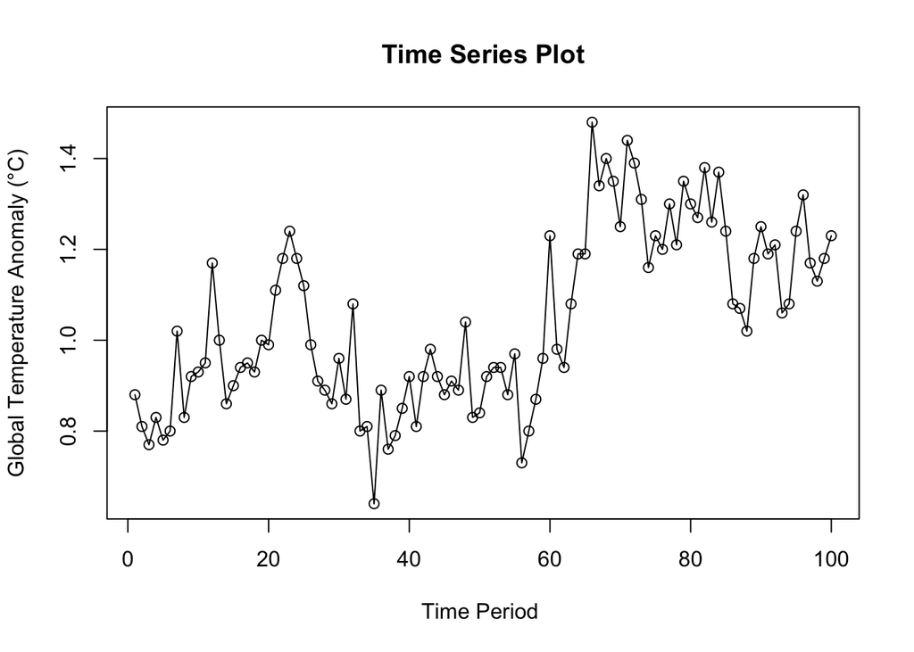

```r
ts.plot(data.ts, xlab="Time Period ", ylab="Global Temperature Anomaly (°C)",
        main = "Time Series Plot")
points(data.ts)
```

```r
#menyimpan plot
dev.copy(png, "plot_data.png")
```

```r
dev.off()
```

## Moving Average

### Pembagian Data

Pembagian data latih dan data uji dilakukan dengan perbandingan 80% data latih dan 20% data uji.

```r
# hitung jumlah data
n <- nrow(data)

# tentukan batas 80%
n_train <- floor(0.8 * n)

# bagi data
training <- data[1:n_train, ]
testing <- data[(n_train+1):n, ]

# ubah ke time series
train.ts <- ts(training$global_temperature_anomaly_C)
test.ts <- ts(testing$global_temperature_anomaly_C)
```

Eksplorasi data dilakukan pada keseluruhan data, data latih serta data uji menggunakan plot data deret waktu.

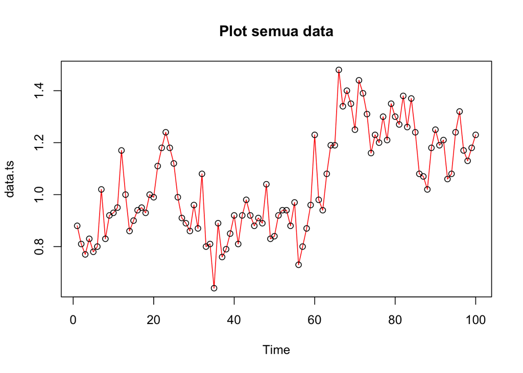

```r
#eksplorasi keseluruhan data
plot(data.ts, col="red",main="Plot semua data")
points(data.ts)
```

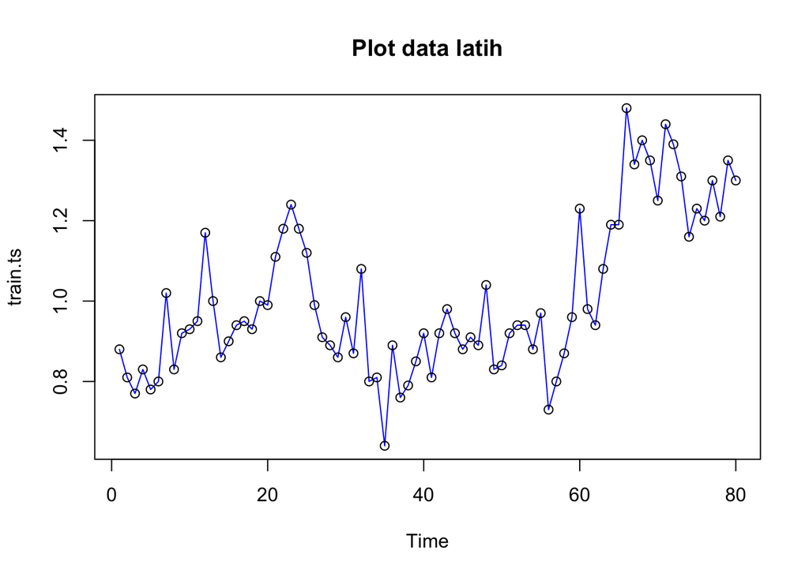

```r
#eksplorasi data latih
plot(train.ts, col="blue",main="Plot data latih")
points(train.ts)
```

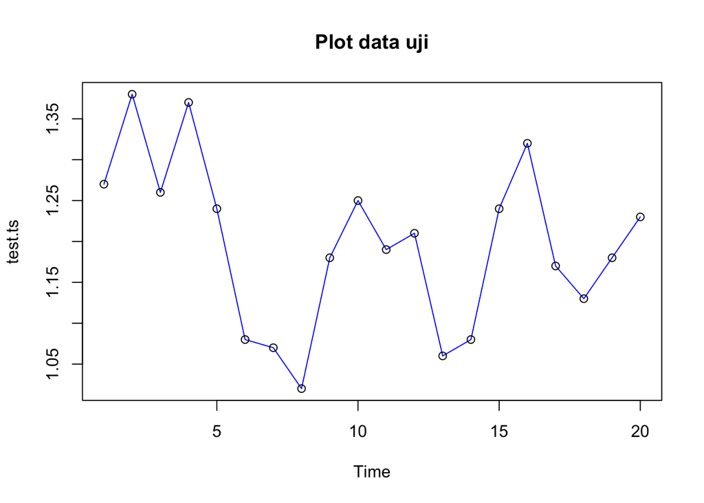

```r
#eksplorasi data uji
plot(test.ts, col="blue",main="Plot data uji")
points(test.ts)
```

### Single Moving Average (SMA)

Ide dasar dari Single Moving Average (SMA) adalah data suatu periode dipengaruhi oleh data periode sebelumnya. Metode pemulusan ini cocok digunakan untuk pola data stasioner atau konstan. Prinsip dasar metode pemulusan ini adalah data pemulusan pada periode ke-t merupakan rata rata dari m buah data pada periode ke-t hingga periode ke (t-m+1).

$$S_t = \frac{1}{m} \sum_{i=t-m+1}^{t} X_i$$
$$S_t = \frac{1}{m}
\sum_{i=t-m+1}^{t} X_i$$

Data pemulusan pada periode ke-t selanjutnya digunakan sebagai nilai peramalan pada periode ke t+1.

$$F_t = S_{t-1}, F_{n,h} =
S_n$$

Pemulusan menggunakan metode SMA dilakukan dengan fungsi `SMA()`. Dalam hal ini akan dilakukan pemulusan dengan parameter `m=4`.

```r
data.sma <- SMA(train.ts, n=4)
data.sma
```

```
## Time Series:
## Start = 1
## End = 80
## Frequency = 1
##  [1]     NA     NA     NA 0.8225 0.7975 0.7950 0.8575 0.8575 0.8925 0.9250
## [11] 0.9075 0.9925 1.0125 0.9950 0.9825 0.9250 0.9125 0.9300 0.9550 0.9675
## [21] 1.0075 1.0700 1.1300 1.1775 1.1800 1.1325 1.0500 0.9775 0.9125 0.9050
## [31] 0.8950 0.9425 0.9275 0.8900 0.8325 0.7850 0.7750 0.7700 0.8225 0.8300
## [41] 0.8425 0.8750 0.9075 0.9075 0.9250 0.9225 0.9000 0.9300 0.9175 0.9000
## [51] 0.9075 0.8825 0.9100 0.9200 0.9325 0.8800 0.8450 0.8425 0.8400 0.9650
## [61] 1.0100 1.0275 1.0575 1.0475 1.1000 1.2350 1.3000 1.3525 1.3925 1.3350
## [71] 1.3600 1.3575 1.3475 1.3250 1.2725 1.2250 1.2225 1.2350 1.2650 1.2900
```

Data pemulusan pada periode ke-t selanjutnya digunakan sebagai nilai peramalan pada periode ke t+1 sehingga hasil peramalan 1 periode kedepan adalah sebagai berikut.

```r
data.ramal <- c(NA,data.sma)
data.ramal
```

```
##  [1]     NA     NA     NA     NA 0.8225 0.7975 0.7950 0.8575 0.8575 0.8925
## [11] 0.9250 0.9075 0.9925 1.0125 0.9950 0.9825 0.9250 0.9125 0.9300 0.9550
## [21] 0.9675 1.0075 1.0700 1.1300 1.1775 1.1800 1.1325 1.0500 0.9775 0.9125
## [31] 0.9050 0.8950 0.9425 0.9275 0.8900 0.8325 0.7850 0.7750 0.7700 0.8225
## [41] 0.8300 0.8425 0.8750 0.9075 0.9075 0.9250 0.9225 0.9000 0.9300 0.9175
## [51] 0.9000 0.9075 0.8825 0.9100 0.9200 0.9325 0.8800 0.8450 0.8425 0.8400
## [61] 0.9650 1.0100 1.0275 1.0575 1.0475 1.1000 1.2350 1.3000 1.3525 1.3925
## [71] 1.3350 1.3600 1.3575 1.3475 1.3250 1.2725 1.2250 1.2225 1.2350 1.2650
## [81] 1.2900
```

Selanjutnya dilakukan peramalan sebanyak 20 periode sesuai dengan jumlah data uji. Pada metode SMA, seluruh hasil peramalan untuk 20 periode ke depan akan memiliki nilai yang sama dengan hasil ramalan satu periode ke depan.

```r
data.gab <- cbind(
  aktual=c(data.ts),
  pemulusan=c(data.sma,rep(NA,20)),
  ramalan=c(data.ramal,rep(data.ramal[length(data.ramal)],19)))
data.gab
```

```
##        aktual pemulusan ramalan
##   [1,]   0.88        NA      NA
##   [2,]   0.81        NA      NA
##   [3,]   0.77        NA      NA
##   [4,]   0.83    0.8225      NA
##   [5,]   0.78    0.7975  0.8225
##   [6,]   0.80    0.7950  0.7975
##   [7,]   1.02    0.8575  0.7950
##   [8,]   0.83    0.8575  0.8575
##   [9,]   0.92    0.8925  0.8575
##  [10,]   0.93    0.9250  0.8925
##  [11,]   0.95    0.9075  0.9250
##  [12,]   1.17    0.9925  0.9075
##  [13,]   1.00    1.0125  0.9925
##  [14,]   0.86    0.9950  1.0125
```

[output cut: 86 more lines]

Adapun plot data deret waktu dari hasil peramalan yang dilakukan adalah sebagai berikut.

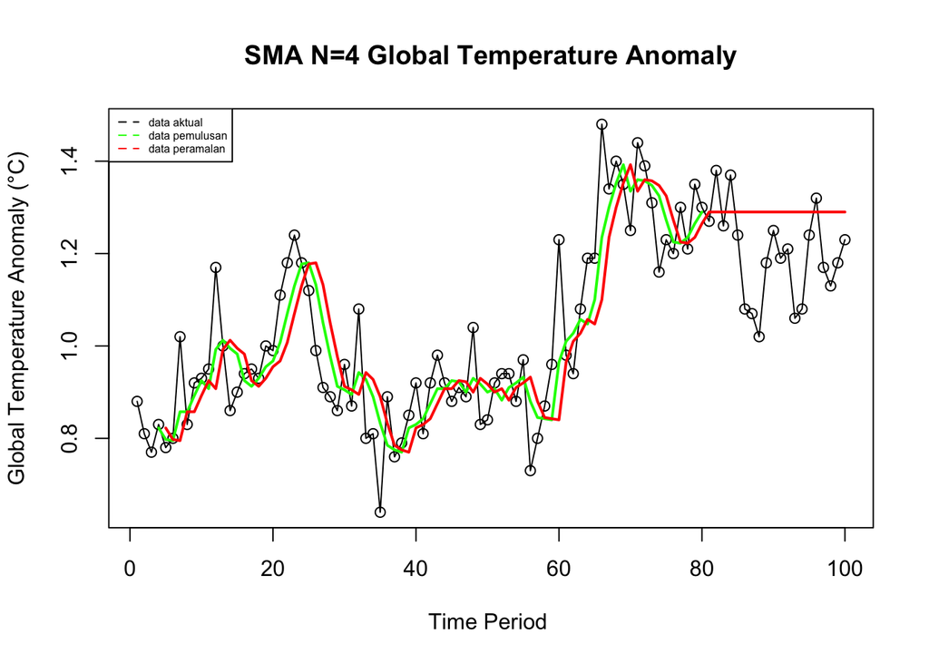

```r
ts.plot(data.ts,
        xlab="Time Period ",
        ylab="Global Temperature Anomaly (°C)",
        main= "SMA N=4 Global Temperature Anomaly")
points(data.ts)
lines(data.gab[,2],col="green",lwd=2)
lines(data.gab[,3],col="red",lwd=2)
legend("topleft",
       c("data aktual","data pemulusan","data peramalan"),
       lty=8,
       col=c("black","green","red"),
       cex=0.5)
```

Selanjutnya perhitungan akurasi dilakukan dengan ukuran akurasi *Sum Squares Error* (SSE), *Mean Square Error* (MSE) dan *Mean Absolute Percentage Error* (MAPE). Perhitungan akurasi dilakukan baik pada data latih maupun pada data uji.

$$SSE = \sum_{t=1}^{n} (y_t -
\hat{y}_t)^2$$

$$MSE = \frac{1}{n} \sum_{t=1}^{n} (y_t -
\hat{y}_t)^2$$

$$MAPE = \frac{1}{n} \sum_{t=1}^{n}
\left|\frac{y_t - \hat{y}_t}{y_t}\right| * 100$$

#### Akurasi Data Latih

```r
#Menghitung nilai keakuratan data latih
error_train.sma = train.ts-data.ramal[1:length(train.ts)]

SSE_train.sma = sum(error_train.sma[5:length(train.ts)]^2)
MSE_train.sma = mean(error_train.sma[5:length(train.ts)]^2)
RMSE_train.sma = sqrt(MSE_train.sma)
MAPE_train.sma = mean(abs((error_train.sma[5:length(train.ts)]/train.ts[5:length(train.ts)])*100))

akurasi_train.sma <- matrix(c(SSE_train.sma,
                              MSE_train.sma,
                              RMSE_train.sma,
                              MAPE_train.sma))
row.names(akurasi_train.sma)<- c("SSE","MSE","RMSE","MAPE")
colnames(akurasi_train.sma) <- c("Akurasi m=4")
akurasi_train.sma
```

```
##      Akurasi m=4
## SSE   1.12606250
## MSE   0.01481661
## RMSE  0.12172351
## MAPE  9.10262559
```

Dalam hal ini nilai MAPE data latih pada metode pemulusan SMA sekitar 9,10%, nilai ini dapat dikategorikan sebagai nilai akurasi yang sangat baik. Selanjutnya dilakukan perhitungan nilai MAPE data uji pada metode pemulusan SMA.

#### Akurasi Data Uji

```r
#Menghitung nilai keakuratan data uji
error_test.sma = test.ts-data.gab[81:100,3]

SSE_test.sma = sum(error_test.sma^2)
MSE_test.sma = mean(error_test.sma^2)
RMSE_test.sma = sqrt(MSE_test.sma)
MAPE_test.sma = mean(abs((error_test.sma/test.ts)*100))

akurasi_test.sma <- matrix(c(SSE_test.sma,
                             MSE_test.sma,
                             RMSE_test.sma,
                             MAPE_test.sma))
row.names(akurasi_test.sma)<- c("SSE", "MSE", "RMSE", "MAPE")
colnames(akurasi_test.sma) <- c("Akurasi m = 4")
akurasi_test.sma
```

```
##      Akurasi m = 4
## SSE      0.3699000
## MSE      0.0184950
## RMSE     0.1359963
## MAPE    10.0212621
```

### Double Moving Average (DMA)

Metode pemulusan Double Moving Average (DMA) pada dasarnya mirip dengan SMA. Namun demikian, metode ini lebih cocok digunakan untuk pola data trend. Proses pemulusan dengan rata rata dalam metode ini dilakukan sebanyak 2 kali.

- **Tahap I:**

$$S_{1,t} = \frac{1}{m} \sum_{i=t-m+1}^{t}
X_i$$

- **Tahap II:**

$$S_{2,t} = \frac{1}{m} \sum_{i=t-m+1}^{t}
S_{1,i}$$

Forecast $h$ langkah ke depan dihitung dengan:

$$F_{2,t,t+h} = A_t + B_t
\,(h)$$

dengan komponen level ($A_t$) dan tren ($B_t$):

$$A_t = 2S_{1,t} - S_{2,t}
\qquad\text{dan}\qquad
B_t = \frac{2}{m-1}\,\big(S_{1,t} - S_{2,t}\big)$$

```r
dma <- SMA(data.sma, n = 4)
At <- 2*data.sma - dma
Bt <- 2/(4-1)*(data.sma - dma)
data.dma<- At+Bt
data.ramal2<- c(NA, data.dma)

t = 1:20
f = c()

for (i in t) {
  f[i] = At[length(At)] + Bt[length(Bt)]*(i)
}

data.gab2 <- cbind(aktual = c(data.ts),
                   pemulusan1 = c(data.sma,rep(NA,20)),
                   pemulusan2 = c(dma, rep(NA,20)),
                   At = c(At, rep(NA,20)),
                   Bt = c(Bt,rep(NA,20)),
                   ramalan = c(data.ramal2, f[-1]))
data.gab2
```

```
##        aktual pemulusan1 pemulusan2       At            Bt   ramalan
##   [1,]   0.88         NA         NA       NA            NA        NA
##   [2,]   0.81         NA         NA       NA            NA        NA
##   [3,]   0.77         NA         NA       NA            NA        NA
##   [4,]   0.83     0.8225         NA       NA            NA        NA
##   [5,]   0.78     0.7975         NA       NA            NA        NA
##   [6,]   0.80     0.7950         NA       NA            NA        NA
##   [7,]   1.02     0.8575   0.818125 0.896875  2.625000e-02        NA
##   [8,]   0.83     0.8575   0.826875 0.888125  2.041667e-02 0.9231250
##   [9,]   0.92     0.8925   0.850625 0.934375  2.791667e-02 0.9085417
##  [10,]   0.93     0.9250   0.883125 0.966875  2.791667e-02 0.9622917
##  [11,]   0.95     0.9075   0.895625 0.919375  7.916667e-03 0.9947917
##  [12,]   1.17     0.9925   0.929375 1.055625  4.208333e-02 0.9272917
##  [13,]   1.00     1.0125   0.959375 1.065625  3.541667e-02 1.0977083
##  [14,]   0.86     0.9950   0.976875 1.013125  1.208333e-02 1.1010417
```

[output cut: 86 more lines]

Hasil pemulusan menggunakan metode DMA divisualisasikan sebagai berikut

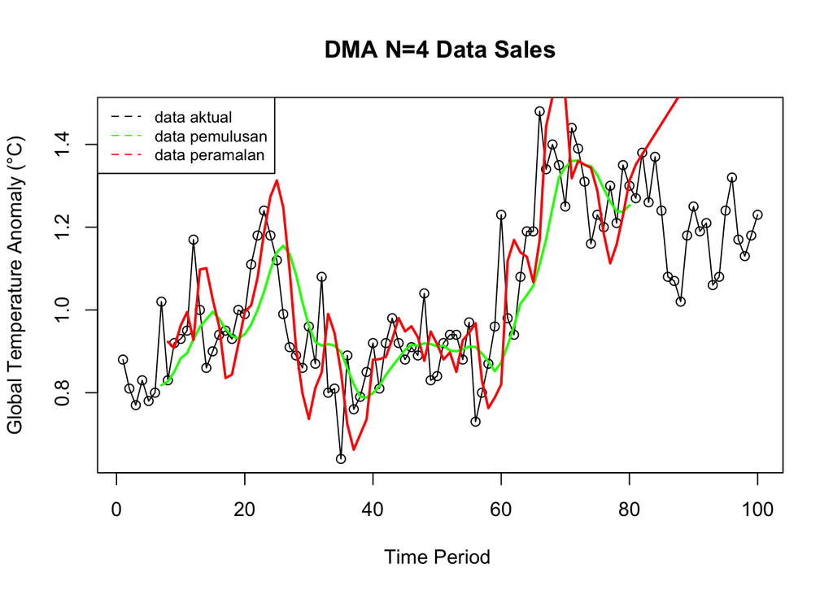

```r
ts.plot(data.ts,
        xlab="Time Period ",
        ylab="Global Temperature Anomaly (°C)",
        main= "DMA N=4 Data Sales")
points(data.ts)
lines(data.gab2[,3],col="green",lwd=2)
lines(data.gab2[,6],col="red",lwd=2)

legend("topleft",
       c("data aktual","data pemulusan","data peramalan"),
       lty=8,
       col=c("black","green","red"),
       cex=0.8)
```

Selanjutnya perhitungan akurasi dilakukan baik pada data latih maupun data uji. Perhitungan akurasi dilakukan dengan ukuran akurasi SSE, MSE dan MAPE.

#### Akurasi Data Latih

```r
#Menghitung nilai keakuratan data latih
error_train.dma = train.ts-data.ramal2[1:length(train.ts)]

SSE_train.dma = sum(error_train.dma[8:length(train.ts)]^2)
MSE_train.dma = mean(error_train.dma[8:length(train.ts)]^2)
RMSE_train.dma = sqrt(MSE_train.dma)

MAPE_train.dma = mean(abs((error_train.dma[8:length(train.ts)]/ train.ts[8:length(train.ts)])*100))

akurasi_train.dma <- matrix(c(SSE_train.dma,
                              MSE_train.dma,
                              RMSE_train.dma,
                              MAPE_train.dma))

row.names(akurasi_train.dma)<- c("SSE", "MSE", "RMSE", "MAPE")
colnames(akurasi_train.dma) <- c("Akurasi m = 4")
akurasi_train.dma
```

```
##      Akurasi m = 4
## SSE     1.39269314
## MSE     0.01907799
## RMSE    0.13812309
## MAPE   11.17928716
```

Perhitungan akurasi pada data latih menggunakan nilai MAPE menghasilkan nilai MAPE berada di rentang 10% – 20% sehingga dikategorikan baik. Selanjutnya, perhitungan nilai akurasi dilakukan pada data uji.

#### Akurasi Data Uji

```r
#Menghitung nilai keakuratan data uji
error_test.dma = test.ts-data.gab2[81:100,6]

SSE_test.dma = sum(error_test.dma^2)
MSE_test.dma = mean(error_test.dma^2)
RMSE_test.dma = sqrt(MSE_test.dma)

MAPE_test.dma = mean(abs((error_test.dma/test.ts)*100))

akurasi_test.dma <- matrix(c(SSE_test.dma,
                             MSE_test.dma,
                             RMSE_test.dma,
                             MAPE_test.dma))
row.names(akurasi_test.dma)<- c("SSE", "MSE", "RMSE", "MAPE")
colnames(akurasi_test.dma) <- c("Akurasi m = 4")
akurasi_test.dma
```

```
##      Akurasi m = 4
## SSE      3.7652988
## MSE      0.1882649
## RMSE     0.4338951
## MAPE    33.6382781
```

Perhitungan akurasi menggunakan data uji menghasilkan nilai MAPE rentang 20% – 50% sehingga nilai akurasi ini dapat dikategorikan sebagai layak/cukup.

Pada data latih dan uji metode SMA lebih baik dibandingkan dengan metode DMA.

### Single Exponential Smoothing

Single Exponential Smoothing (SES) adalah metode peramalan deret waktu yang dikembangkan untuk mengatasi kelemahan Moving Average. Jika pada Moving Average setiap data periode sebelumnya dianggap memiliki bobot yang sama, maka SES memberikan bobot yang semakin mengecil secara eksponensial terhadap data lama, sehingga data terbaru diberi bobot lebih besar.

Single Exponential Smoothing merupakan metode pemulusan yang tepat digunakan untuk data dengan pola stasioner atau konstan.

Nilai pemulusan pada periode ke-t didapat dari persamaan:

$$\tilde{y}_T=\lambda
y_t+(1-\lambda)\tilde{y}_{T-1}$$

Nilai parameter $\lambda$ adalah nilai antara 0 dan 1.

Nilai pemulusan periode ke-t bertindak sebagai nilai ramalan pada periode ke-$(T+\tau)$.

$$\tilde{y}_{T+\tau}(T)=\tilde{y}_T$$

Pemulusan dengan metode SES dapat dilakukan dengan dua fungsi dari *packages* berbeda, yaitu (1) fungsi `ses()` dari *packages* `forecast` dan (2) fungsi `HoltWinters` dari *packages* `stats` .

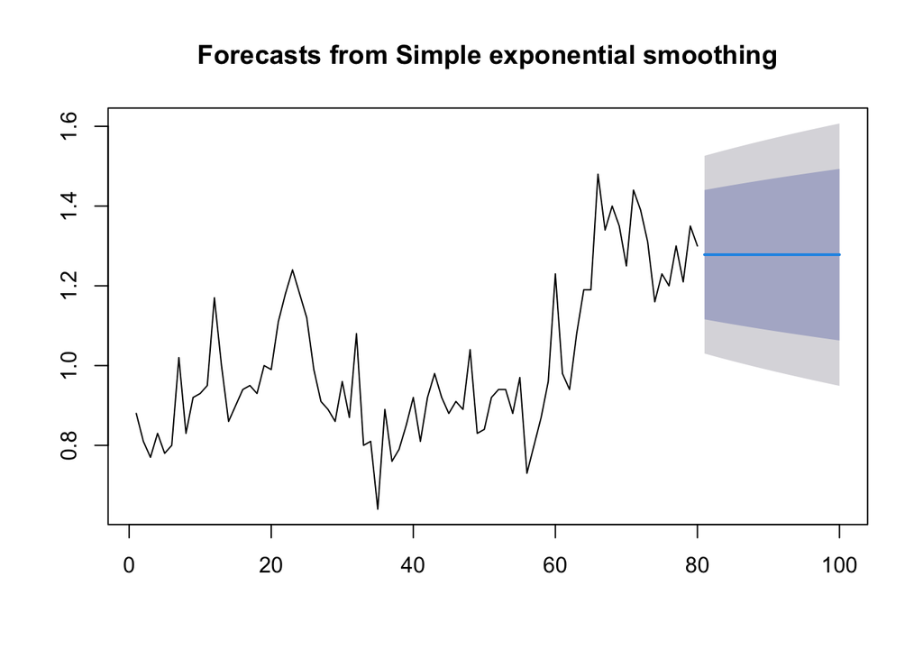

```r
# SES dengan alpha = 0.2
ses.1 <- ses(train.ts, h = 20, alpha = 0.2)
plot(ses.1)
```

```r
ses.1
```

```
##     Point Forecast    Lo 80    Hi 80     Lo 95    Hi 95
##  81       1.278145 1.116006 1.440283 1.0301753 1.526114
##  82       1.278145 1.112795 1.443494 1.0252645 1.531025
##  83       1.278145 1.109645 1.446644 1.0204473 1.535842
##  84       1.278145 1.106553 1.449736 1.0157185 1.540571
##  85       1.278145 1.103516 1.452773 1.0110735 1.545216
##  86       1.278145 1.100531 1.455759 1.0065078 1.549782
##  87       1.278145 1.097595 1.458695 1.0020176 1.554272
##  88       1.278145 1.094706 1.461584 0.9975993 1.558690
##  89       1.278145 1.091862 1.464428 0.9932495 1.563040
##  90       1.278145 1.089060 1.467229 0.9889652 1.567324
##  91       1.278145 1.086300 1.469990 0.9847433 1.571546
##  92       1.278145 1.083579 1.472711 0.9805814 1.575708
##  93       1.278145 1.080895 1.475395 0.9764769 1.579813
##  94       1.278145 1.078247 1.478043 0.9724275 1.583862
##  95       1.278145 1.075634 1.480656 0.9684310 1.587859
##  96       1.278145 1.073054 1.483236 0.9644854 1.591804
##  97       1.278145 1.070506 1.485783 0.9605889 1.595701
##  98       1.278145 1.067989 1.488300 0.9567396 1.599550
##  99       1.278145 1.065502 1.490788 0.9529358 1.603354
## 100       1.278145 1.063044 1.493246 0.9491761 1.607114
```

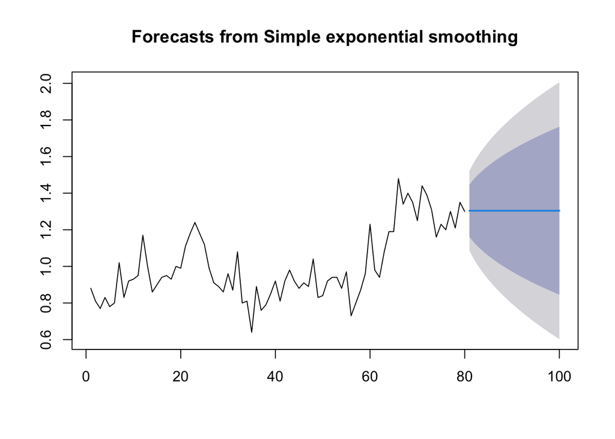

```r
# SES dengan alpha = 0.7
ses.2 <- ses(train.ts, h = 20, alpha = 0.7)
plot(ses.2)
```

```r
ses.2
```

```
##     Point Forecast     Lo 80    Hi 80     Lo 95    Hi 95
##  81        1.30408 1.1611772 1.446983 1.0855290 1.522631
##  82        1.30408 1.1296449 1.478515 1.0373045 1.570855
##  83        1.30408 1.1029979 1.505162 0.9965515 1.611608
##  84        1.30408 1.0794906 1.528669 0.9606002 1.647560
##  85        1.30408 1.0582207 1.549939 0.9280707 1.680089
##  86        1.30408 1.0386498 1.569510 0.8981396 1.710020
##  87        1.30408 1.0204260 1.587734 0.8702687 1.737891
##  88        1.30408 1.0033044 1.604856 0.8440834 1.764077
##  89        1.30408 0.9871062 1.621054 0.8193105 1.788850
##  90        1.30408 0.9716965 1.636463 0.7957434 1.812417
##  91        1.30408 0.9569703 1.651190 0.7732215 1.834938
##  92        1.30408 0.9428439 1.665316 0.7516170 1.856543
##  93        1.30408 0.9292494 1.678911 0.7308261 1.877334
##  94        1.30408 0.9161311 1.692029 0.7107634 1.897397
##  95        1.30408 0.9034421 1.704718 0.6913572 1.916803
##  96        1.30408 0.8911428 1.717017 0.6725471 1.935613
##  97        1.30408 0.8791994 1.728961 0.6542812 1.953879
##  98        1.30408 0.8675827 1.740577 0.6365150 1.971645
##  99        1.30408 0.8562672 1.751893 0.6192094 1.988951
## 100        1.30408 0.8452307 1.762929 0.6023305 2.005829
```

#### Untuk mendapatkan parameter $\lambda$ optimum digunakan alpha = NULL.

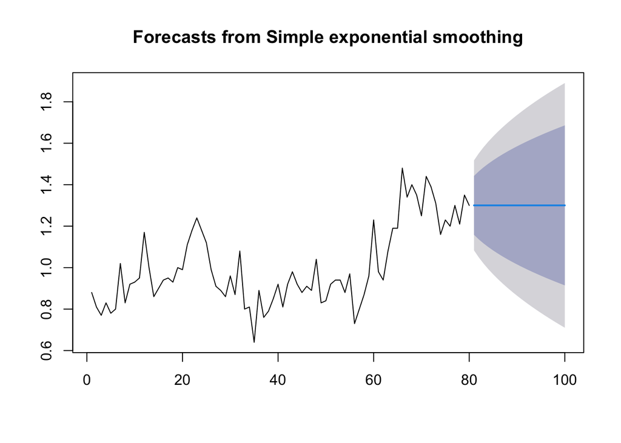

```r
# SES optimum
ses.opt <- ses(train.ts, h = 20, alpha = NULL)
plot(ses.opt)
```

```r
ses.opt
```

```
##     Point Forecast     Lo 80    Hi 80     Lo 95    Hi 95
##  81       1.300297 1.1584032 1.442190 1.0832893 1.517304
##  82       1.300297 1.1362483 1.464345 1.0494063 1.551187
##  83       1.300297 1.1167483 1.483845 1.0195837 1.581010
##  84       1.300297 1.0991298 1.501464 0.9926384 1.607955
##  85       1.300297 1.0829346 1.517659 0.9678701 1.632723
##  86       1.300297 1.0678652 1.532728 0.9448235 1.655770
##  87       1.300297 1.0537151 1.546878 0.9231826 1.677411
##  88       1.300297 1.0403340 1.560259 0.9027180 1.697875
##  89       1.300297 1.0276087 1.572985 0.8832564 1.717337
##  90       1.300297 1.0154513 1.585142 0.8646633 1.735930
##  91       1.300297 1.0037921 1.596801 0.8468320 1.753761
##  92       1.300297 0.9925742 1.608019 0.8296758 1.770918
##  93       1.300297 0.9817512 1.618842 0.8131234 1.787470
##  94       1.300297 0.9712840 1.629309 0.7971152 1.803478
##  95       1.300297 0.9611397 1.639454 0.7816008 1.818993
##  96       1.300297 0.9512901 1.649303 0.7665372 1.834056
##  97       1.300297 0.9417110 1.658882 0.7518872 1.848706
##  98       1.300297 0.9323811 1.668212 0.7376184 1.862975
##  99       1.300297 0.9232821 1.677311 0.7237027 1.876891
## 100       1.300297 0.9143976 1.686196 0.7101150 1.890478
```

Setelah dilakukan peramalan, akan dilakukan perhitungan keakuratan hasil peramalan. Perhitungan akurasi ini dilakukan baik pada data latih dan data uji.

#### Akurasi Data Latih

Perhitungan akurasi data dapat dilakukan dengan cara langsung maupun manual. Secara langsung, nilai akurasi dapat diambil dari objek yang tersimpan pada hasil SES, yaitu *sum of squared errors* (SSE). Nilai akurasi lain dapat dihitung pula dari nilai SSE tersebut.

```r
# Keakuratan Metode
# Pada data training

# SES dengan alpha = 0.2
SSE1 <- sum(residuals(ses.1)^2)
MSE1 <- SSE1 / length(train.ts)
RMSE1 <- sqrt(MSE1)
MAPE1 <- mean(abs(residuals(ses.1) / train.ts)) * 100

akurasi1 <- matrix(
  c(SSE1, MSE1, RMSE1, MAPE1),
  nrow = 4,
  ncol = 1
)
row.names(akurasi1) <- c("SSE", "MSE", "RMSE", "MAPE")
colnames(akurasi1) <- c("Akurasi lamda=0.2")
akurasi1
```

```
##      Akurasi lamda=0.2
## SSE         1.24851842
## MSE         0.01560648
## RMSE        0.12492590
## MAPE        9.24963383
```

```r
# SES dengan alpha = 0.7
SSE2 <- sum(residuals(ses.2)^2)
MSE2 <- SSE2 / length(train.ts)
RMSE2 <- sqrt(MSE2)
MAPE2 <- mean(abs(residuals(ses.2) / train.ts)) * 100

akurasi2 <- matrix(
  c(SSE2, MSE2, RMSE2, MAPE2),
  nrow = 4,
  ncol = 1
)
row.names(akurasi2) <- c("SSE", "MSE", "RMSE", "MAPE")
colnames(akurasi2) <- c("Akurasi lamda=0.7")
akurasi2
```

```
##      Akurasi lamda=0.7
## SSE         0.96984857
## MSE         0.01212311
## RMSE        0.11010498
## MAPE        8.73171918
```

```r
# SES optimum
SSEopt <- sum(residuals(ses.opt)^2)
MSEopt <- SSEopt / length(train.ts)
RMSEopt <- sqrt(MSEopt)
MAPEopt <- mean(abs(residuals(ses.opt) / train.ts)) * 100

akurasopt <- matrix(
  c(SSEopt, MSEopt, RMSEopt, MAPEopt),
  nrow = 4,
  ncol = 1
)
row.names(akurasopt) <- c("SSE", "MSE", "RMSE", "MAPE")
colnames(akurasopt) <- c("Akurasi lamda optimum")
akurasopt
```

```
##      Akurasi lamda optimum
## SSE             0.95619696
## MSE             0.01195246
## RMSE            0.10932732
## MAPE            8.58534789
```

Berdasarkan nilai SSE, MSE, RMSE, dan MAPE di antara kedua parameter, nilai parameter $\lambda=0,7$ menghasilkan akurasi yang lebih baik dibanding $\lambda=0,2$ . Hal ini dilihat dari nilai masing-masing ukuran akurasi yang lebih kecil. Berdasarkan nilai MAPE-nya, hasil ini dapat dikategorikan sebagai peramalan sangat baik.

#### Akurasi Data Uji

Akurasi data uji dapat dihitung dengan cara yang hampir sama dengan perhitungan akurasi data latih.

```r
# jumlah observasi uji
n_test <- nrow(testing)

# error
e1 <- as.numeric(ses.1$mean)[1:n_test] - as.numeric(testing$global_temperature_anomaly_C)
e2 <- as.numeric(ses.2$mean)[1:n_test] - as.numeric(testing$global_temperature_anomaly_C)
eopt <- as.numeric(ses.opt$mean)[1:n_test] - as.numeric(testing$global_temperature_anomaly_C)

# SES alpha = 0.2
SSEtesting1 <- sum(e1^2)
MSEtesting1 <- mean(e1^2)
RMSEtesting1 <- sqrt(MSEtesting1)
MAPEtesting1 <- mean(abs(e1/testing$global_temperature_anomaly_C)*100)

# SES alpha = 0.7
SSEtesting2 <- sum(e2^2)
MSEtesting2 <- mean(e2^2)
RMSEtesting2 <- sqrt(MSEtesting2)
MAPEtesting2 <- mean(abs(e2/testing$global_temperature_anomaly_C)*100)

# SES optimum
SSEtestingopt <- sum(eopt^2)
MSEtestingopt <- mean(eopt^2)
RMSEtestingopt <- sqrt(MSEtestingopt)
MAPEtestingopt <- mean(abs(eopt/testing$global_temperature_anomaly_C)*100)

akurasitesting <- matrix(
  c(SSEtesting1,MSEtesting1,RMSEtesting1,MAPEtesting1,
    SSEtesting2,MSEtesting2,RMSEtesting2,MAPEtesting2,
    SSEtestingopt,MSEtestingopt,RMSEtestingopt,MAPEtestingopt),
  nrow=4,ncol=3)

row.names(akurasitesting)<- c("SSE", "MSE", "RMSE", "MAPE")
colnames(akurasitesting) <- c("SES alpha=0.2",
                                                                                          "SES alpha=0.7",
                                                                                          "SES optimum")
akurasitesting
```

```
##      SES alpha=0.2 SES alpha=0.7 SES optimum
## SSE     0.32837246     0.4265241   0.4105300
## MSE     0.01641862     0.0213262   0.0205265
## RMSE    0.12813517     0.1460349   0.1432707
## MAPE    9.28586037    10.8946714  10.6599852
```

### *Double Exponential Smoothing* (DES)

Metode pemulusan *Double Exponential Smoothing* (DES) digunakan untuk data yang memiliki pola tren. Metode DES adalah metode semacam SES, hanya saja dilakukan dua kali, yaitu pertama untuk tahapan ‘level’ dan kedua untuk tahapan ‘tren’. Pemulusan menggunakan metode ini akan menghasilkan peramalan tidak konstan untuk periode berikutnya.

Pemulusan dengan metode DES kali ini akan menggunakan fungsi `HoltWinters()` . Jika sebelumnya nilai argumen `beta` dibuat `FALSE` , kali ini argumen tersebut akan diinisialisasi bersamaan dengan nilai `alpha` .

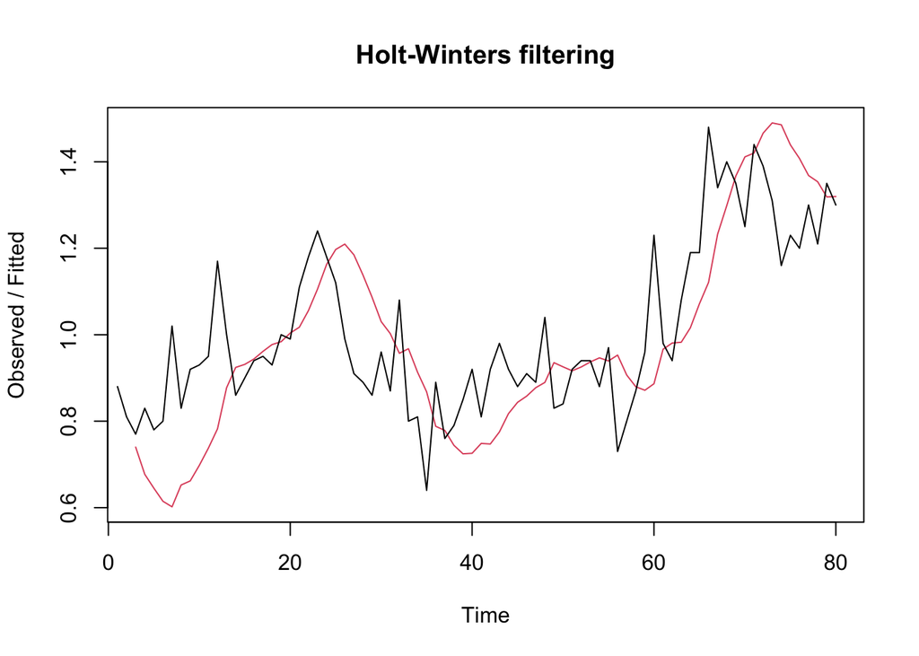

```r
#Lamda=0.2 dan gamma=0.2
des.1<- HoltWinters(train.ts, gamma = FALSE, beta = 0.2, alpha = 0.2)
plot(des.1)
```

```r
#ramalan
ramalandes1<- forecast(des.1, h=20)
ramalandes1
```

```
##     Point Forecast     Lo 80    Hi 80     Lo 95    Hi 95
##  81       1.309795 1.1093709 1.510219 1.0032728 1.616317
##  82       1.303812 1.0976968 1.509928 0.9885859 1.619038
##  83       1.297829 1.0842110 1.511448 0.9711282 1.624531
##  84       1.291847 1.0688081 1.514885 0.9507386 1.632955
##  85       1.285864 1.0514451 1.520283 0.9273512 1.644377
##  86       1.279881 1.0321327 1.527630 0.9009825 1.658780
##  87       1.273899 1.0109229 1.536875 0.8717119 1.676086
##  88       1.267916 0.9878957 1.547936 0.8396618 1.696170
##  89       1.261933 0.9631469 1.560720 0.8049790 1.718888
##  90       1.255951 0.9367790 1.575122 0.7678197 1.744082
##  91       1.249968 0.9088937 1.591042 0.7283398 1.771596
##  92       1.243985 0.8795882 1.608382 0.6866881 1.801282
##  93       1.238003 0.8489528 1.627052 0.6430023 1.833003
##  94       1.232020 0.8170696 1.646970 0.5974082 1.866632
##  95       1.226037 0.7840125 1.668062 0.5500188 1.902056
##  96       1.220055 0.7498477 1.690261 0.5009352 1.939174
##  97       1.214072 0.7146339 1.713510 0.4502474 1.977896
##  98       1.208089 0.6784235 1.737755 0.3980354 2.018143
##  99       1.202106 0.6412629 1.762950 0.3443703 2.059843
## 100       1.196124 0.6031938 1.789054 0.2893157 2.102932
```

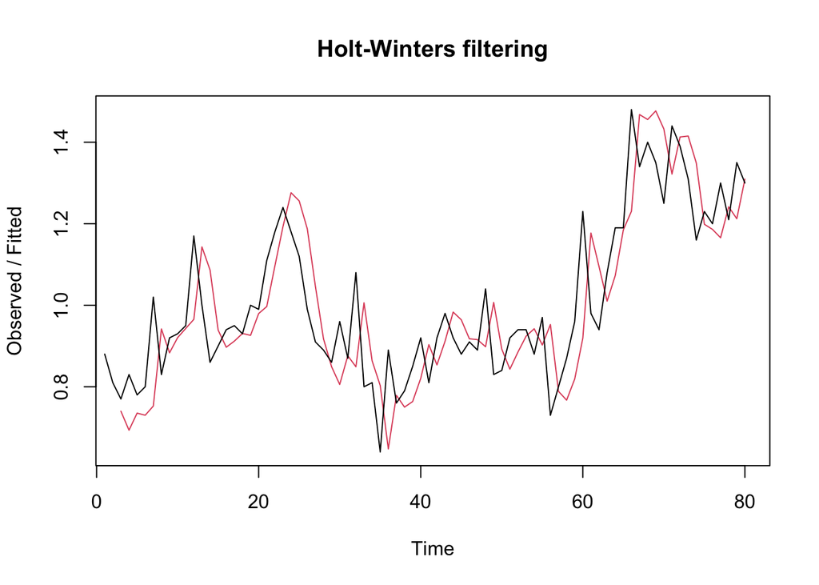

```r
#Lamda=0.6 dan gamma=0.3
des.2<- HoltWinters(train.ts, gamma = FALSE, beta = 0.3, alpha = 0.6)
plot(des.2)
```

```r
#ramalan
ramalandes2<- forecast(des.2, h=20)
ramalandes2
```

```
##     Point Forecast       Lo 80    Hi 80      Lo 95    Hi 95
##  81       1.316511  1.15921829 1.473803  1.0759527 1.557069
##  82       1.329273  1.12979039 1.528756  1.0241907 1.634355
##  83       1.342035  1.09184618 1.592224  0.9594041 1.724666
##  84       1.354797  1.04698601 1.662609  0.8840405 1.825554
##  85       1.367560  0.99626936 1.738850  0.7997202 1.935399
##  86       1.380322  0.94040871 1.820235  0.7075328 2.053111
##  87       1.393084  0.87990536 1.906263  0.6082450 2.177923
##  88       1.405846  0.81512967 1.996563  0.5024232 2.309269
##  89       1.418609  0.74636748 2.090850  0.3905046 2.446712
##  90       1.431371  0.67384764 2.188894  0.2728391 2.589902
##  91       1.444133  0.59775890 2.290507  0.1497156 2.738550
##  92       1.456895  0.51826074 2.395530  0.0213777 2.892413
##  93       1.469657  0.43549050 2.503824 -0.1119644 3.051279
##  94       1.482420  0.34956838 2.615271 -0.2501268 3.214966
##  95       1.495182  0.26060090 2.729763 -0.3929467 3.383310
##  96       1.507944  0.16868348 2.847205 -0.5402782 3.556166
##  97       1.520706  0.07390237 2.967510 -0.6919893 3.733402
##  98       1.533468 -0.02366388 3.090601 -0.8479599 3.914897
##  99       1.546231 -0.12394328 3.216405 -1.0080799 4.100541
## 100       1.558993 -0.22686949 3.344855 -1.1722479 4.290234
```

Selanjutnya jika ingin membandingkan plot data latih dan data uji adalah sebagai berikut.

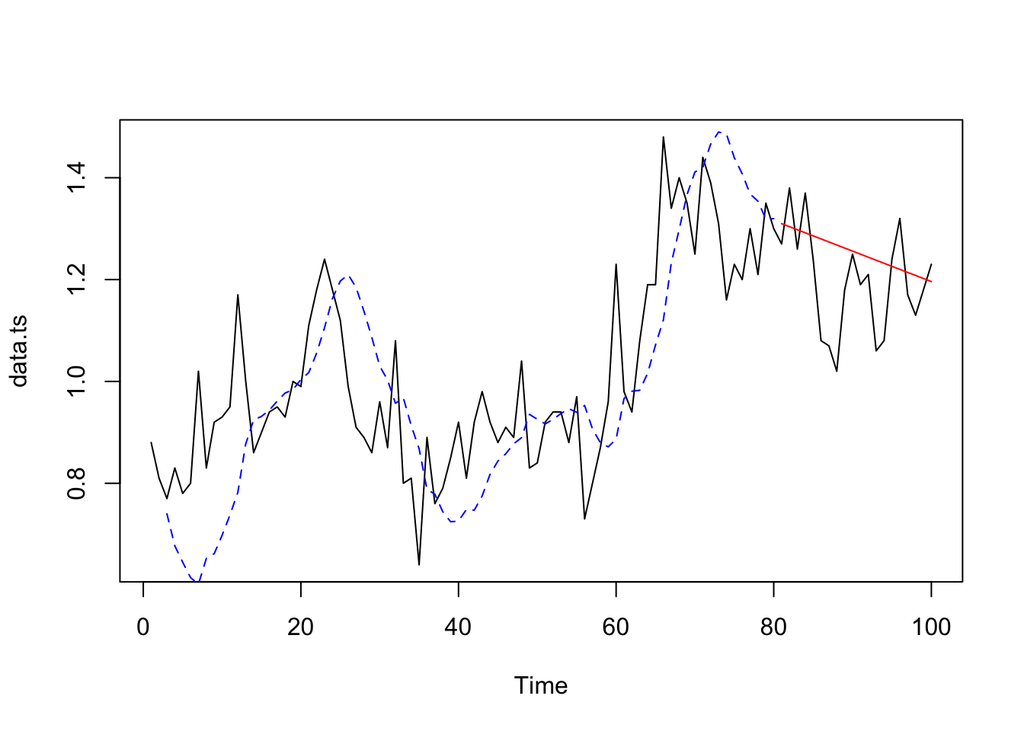

```r
plot(data.ts)
lines(des.1$fitted[,1], lty=2, col="blue")
lines(ramalandes1$mean, col="red")
```

Untuk mendapatkan nilai parameter optimum dari DES, argumen `alpha` dan `beta` dapat dibuat `NULL` seperti berikut.

```r
#Lamda dan gamma optimum
des.opt<- HoltWinters(train.ts, gamma = FALSE)
des.opt
```

```
## Holt-Winters exponential smoothing with trend and without seasonal component.
##
## Call:
## HoltWinters(x = train.ts, gamma = FALSE)
##
## Smoothing parameters:
##  alpha: 0.6755771
##  beta : 0.09660245
##  gamma: FALSE
##
## Coefficients:
##          [,1]
## a 1.307104671
## b 0.008136226
```

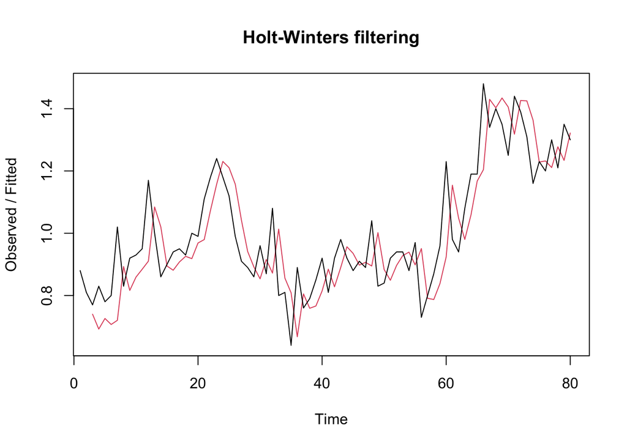

```r
plot(des.opt)
```

```r
#ramalan
ramalandesopt<- forecast(des.opt, h=20)
ramalandesopt
```

```
##     Point Forecast     Lo 80    Hi 80      Lo 95    Hi 95
##  81       1.315241 1.1634369 1.467045 1.08307673 1.547405
##  82       1.323377 1.1344532 1.512301 1.03444295 1.612311
##  83       1.331513 1.1064211 1.556606 0.98726443 1.675762
##  84       1.339650 1.0785679 1.600731 0.94035967 1.738939
##  85       1.347786 1.0504984 1.645073 0.89312391 1.802448
##  86       1.355922 1.0219888 1.689855 0.84521519 1.866629
##  87       1.364058 0.9929050 1.735211 0.79642837 1.931688
##  88       1.372194 0.9631639 1.781225 0.74663616 1.997753
##  89       1.380331 0.9327130 1.827948 0.69575844 2.064903
##  90       1.388467 0.9015194 1.875414 0.64374499 2.133189
##  91       1.396603 0.8695633 1.923643 0.59056526 2.202641
##  92       1.404739 0.8368333 1.972645 0.53620194 2.273277
##  93       1.412876 0.8033240 2.022427 0.48064682 2.345104
##  94       1.421012 0.7690342 2.072990 0.42389805 2.418126
##  95       1.429148 0.7339656 2.124331 0.36595824 2.492338
##  96       1.437284 0.6981220 2.176447 0.30683316 2.567735
##  97       1.445421 0.6615087 2.229332 0.24653083 2.644310
##  98       1.453557 0.6241318 2.282982 0.18506081 2.722053
##  99       1.461693 0.5859984 2.337388 0.12243374 2.800952
## 100       1.469829 0.5471159 2.392542 0.05866102 2.880997
```

Selanjutnya akan dilakukan perhitungan akurasi pada data latih maupun data uji dengan ukuran akurasi SSE, MSE dan MAPE.

#### Akurasi Data Latih

```r
#Akurasi Data Training
ssedes.train1<-des.1$SSE
msedes.train1<-ssedes.train1/length(train.ts)
sisaandes1<-ramalandes1$residuals
head(sisaandes1)
```

```
## Time Series:
## Start = 1
## End = 6
## Frequency = 1
## [1]        NA        NA 0.0300000 0.1528000 0.1349280 0.1852333
```

```r
mapedes.train1 <- sum(abs(sisaandes1[3:length(train.ts)]/train.ts[3:length(train.ts)])
                      *100)/length(train.ts)

akurasides.1 <- matrix(c(ssedes.train1,msedes.train1,mapedes.train1))
row.names(akurasides.1)<- c("SSE", "MSE", "MAPE")
colnames(akurasides.1) <- c("Akurasi lamda=0.2 dan gamma=0.2")
akurasides.1
```

```
##      Akurasi lamda=0.2 dan gamma=0.2
## SSE                       1.91613161
## MSE                       0.02395165
## MAPE                     12.11327664
```

```r
ssedes.train2<-des.2$SSE
msedes.train2<-ssedes.train2/length(train.ts)
sisaandes2<-ramalandes2$residuals
head(sisaandes2)
```

```
## Time Series:
## Start = 1
## End = 6
## Frequency = 1
## [1]         NA         NA 0.03000000 0.13660000 0.04465200 0.06983544
```

```r
mapedes.train2 <- sum(abs(sisaandes2[3:length(train.ts)]/train.ts[3:length(train.ts)])
                      *100)/length(train.ts)

akurasides.2 <- matrix(c(ssedes.train2,msedes.train2,mapedes.train2))
row.names(akurasides.2)<- c("SSE", "MSE", "MAPE")
colnames(akurasides.2) <- c("Akurasi lamda=0.6 dan gamma=0.3")
akurasides.2
```

```
##      Akurasi lamda=0.6 dan gamma=0.3
## SSE                        1.1626480
## MSE                        0.0145331
## MAPE                       9.5297702
```

Hasil akurasi dari data latih didapatkan skenario 2 dengan lamda=0.6 dan gamma=0.3 memiliki hasil yang lebih baik. Namun untuk skenario 1 dapat dikategorikan peramalan baik berdasarkan nilai MAPE-nya dan skenario 2 sangat baik.

#### Akurasi Data Uji

```r
#Akurasi Data Testing
selisihdes1<-ramalandes1$mean-testing$global_temperature_anomaly_C
selisihdes1
```

```
## Time Series:
## Start = 81
## End = 100
## Frequency = 1
##  [1]  0.039794878 -0.076187814  0.037829495 -0.078153197  0.045864112
##  [6]  0.199881421  0.203898729  0.247916038  0.081933347  0.005950655
## [11]  0.059967964  0.033985272  0.178002581  0.152019890 -0.013962802
## [16] -0.099945493  0.044071815  0.078089124  0.022106433 -0.033876259
```

```r
SSEtestingdes1<-sum(selisihdes1^2)
MSEtestingdes1<-SSEtestingdes1/length(testing$global_temperature_anomaly_C)
RMSEtestingdes1<-sqrt(MSEtestingdes1)
MAPEtestingdes1<-sum(abs(selisihdes1/
                           testing$global_temperature_anomaly_C)*100)/
  length(testing$global_temperature_anomaly_C)

selisihdes2<-ramalandes2$mean-testing$global_temperature_anomaly_C
selisihdes2
```

```
## Time Series:
## Start = 81
## End = 100
## Frequency = 1
##  [1]  0.04651080 -0.05072698  0.08203523 -0.01520256  0.12755965  0.30032187
##  [7]  0.32308408  0.38584629  0.23860850  0.18137072  0.25413293  0.24689514
## [13]  0.40965735  0.40241957  0.25518178  0.18794399  0.35070620  0.40346842
## [19]  0.36623063  0.32899284
```

```r
SSEtestingdes2<-sum(selisihdes2^2)
MSEtestingdes2<-SSEtestingdes2/length(testing$global_temperature_anomaly_C)
RMSEtestingdes2<-sqrt(MSEtestingdes2)
MAPEtestingdes2<-sum(abs(selisihdes2/
                           testing$global_temperature_anomaly_C)*100)/
length(testing$global_temperature_anomaly_C)

selisihdesopt<-ramalandesopt$mean-testing$global_temperature_anomaly_C
selisihdesopt
```

```
## Time Series:
## Start = 81
## End = 100
## Frequency = 1
##  [1]  0.04524090 -0.05662288  0.07151335 -0.03035042  0.10778580  0.27592203
##  [7]  0.29405826  0.35219448  0.20033071  0.13846693  0.20660316  0.19473939
## [13]  0.35287561  0.34101184  0.18914807  0.11728429  0.27542052  0.32355675
## [19]  0.28169297  0.23982920
```

```r
SSEtestingdesopt<-sum(selisihdesopt^2)
MSEtestingdesopt<-SSEtestingdesopt/length(testing$global_temperature_anomaly_C)
RMSEtestingdesopt<-sqrt(MSEtestingdesopt)
MAPEtestingdesopt<-sum(abs(selisihdesopt/
                             testing$global_temperature_anomaly_C)*100)/
  length(testing$global_temperature_anomaly_C)

akurasitestingdes <-
  matrix(c(SSEtestingdes1,MSEtestingdes1,RMSEtestingdes1,MAPEtestingdes1,
           SSEtestingdes2,MSEtestingdes2,RMSEtestingdes2,MAPEtestingdes2,
           SSEtestingdesopt,MSEtestingdesopt,RMSEtestingdesopt,MAPEtestingdesopt),
         nrow=4,ncol=3)

row.names(akurasitestingdes)<- c("SSE", "MSE", "RMSE", "MAPE")
colnames(akurasitestingdes) <- c("des ske1","des ske2","des opt")

akurasitestingdes
```

```
##        des ske1    des ske2     des opt
## SSE  0.24617556  1.54513697  1.05722121
## MSE  0.01230878  0.07725685  0.05286106
## RMSE 0.11094493  0.27795116  0.22991533
## MAPE 7.65338920 21.58781524 17.89334627
```

#### Perbandingan SES dan DES

```r
MSEfull <- matrix(c(MSE_test.sma,
MSE_test.dma,
MSEtesting1,
MSEtesting2,
MSEtestingopt,
MSEtestingdes1,
MSEtestingdes2,
MSEtestingdesopt),
nrow=8,ncol=1)

row.names(MSEfull)<- c("SMA",
                       "DMA",
                       "SES alpha=0.2",
                       "SES alpha=0.7",
                       "SES optimum",
                       "DES skenario 1",
                       "DES skenario 2",
                       "DES optimum")

colnames(MSEfull) <- c("MSE Data Uji")

MSEfull
```

```
##                MSE Data Uji
## SMA              0.01849500
## DMA              0.18826494
## SES alpha=0.2    0.01641862
## SES alpha=0.7    0.02132620
## SES optimum      0.02052650
## DES skenario 1   0.01230878
## DES skenario 2   0.07725685
## DES optimum      0.05286106
```

# Perbandingan SSE, MSE, RMSE dan MAPE data uji

```r
perbandingan <-
  matrix(c(
    SSE_test.sma, MSE_test.sma, RMSE_test.sma, MAPE_test.sma,
    SSE_test.dma, MSE_test.dma, RMSE_test.dma, MAPE_test.dma,
    SSEtesting1, MSEtesting1, RMSEtesting1, MAPEtesting1,
    SSEtesting2, MSEtesting2, RMSEtesting2, MAPEtesting2,
    SSEtestingopt, MSEtestingopt, RMSEtestingopt, MAPEtestingopt,
    SSEtestingdes1, MSEtestingdes1, RMSEtestingdes1, MAPEtestingdes1,
    SSEtestingdes2, MSEtestingdes2, RMSEtestingdes2, MAPEtestingdes2,
    SSEtestingdesopt, MSEtestingdesopt, RMSEtestingdesopt, MAPEtestingdesopt
  ),
  nrow=4,
  ncol=8)

row.names(perbandingan) <- c("SSE", "MSE", "RMSE", "MAPE")

colnames(perbandingan) <- c(
  "SMA",
  "DMA",
  "SES 0.2",
  "SES 0.7",
  "SES opt",
  "DES 0.2;0.2",
  "DES 0.6;0.3",
  "DES opt")

perbandingan
```

```
##             SMA        DMA    SES 0.2    SES 0.7    SES opt DES 0.2;0.2
## SSE   0.3699000  3.7652988 0.32837246  0.4265241  0.4105300  0.24617556
## MSE   0.0184950  0.1882649 0.01641862  0.0213262  0.0205265  0.01230878
## RMSE  0.1359963  0.4338951 0.12813517  0.1460349  0.1432707  0.11094493
## MAPE 10.0212621 33.6382781 9.28586037 10.8946714 10.6599852  7.65338920
##      DES 0.6;0.3     DES opt
## SSE   1.54513697  1.05722121
## MSE   0.07725685  0.05286106
## RMSE  0.27795116  0.22991533
## MAPE 21.58781524 17.89334627
```

Kedua metode dapat dibandingkan dengan menggunakan ukuran akurasi yang sama. Contoh di atas adalah perbandingan kedua metode dengan ukuran akurasi MSE. Hasilnya didapatkan metode DES sangat unggul jika menggunakan Skenario 1 (α=0.2,β=0.2) dengan MSE 0.0123 dan MAPE 7.65%.